# DINOv2 Embedding POC — Before Fine-Tuning

**Goal:** evaluate whether pretrained **DINOv2 embeddings** contain useful patterns for the wheat-grain dataset **before any fine-tuning**.

This notebook does **not** train DINOv2 and does **not** make the final class prediction.

### Flow

`YOLO-Seg labeled dataset → Extract individual grain crops → Pretrained DINOv2 (frozen) → Embeddings → Analyze patterns/separability`

### What this notebook checks

- Dataset/classes and number of labeled grain instances
- DINOv2 embeddings for each grain
- PCA visualization
- Optional t-SNE visualization
- Class-centroid cosine similarity
- Silhouette score
- Nearest-neighbor same-class consistency
- Save embeddings for later RF / XGBoost / CatBoost / SVM experiments

> Assumption: labels are in **YOLO segmentation polygon format**.  
> Class names are read automatically from `data.yaml` when available.

## 1. Install dependencies

```python
%pip install -q torch torchvision opencv-python pillow pandas numpy matplotlib scikit-learn pyyaml tqdm
```

```
c:\Users\alool\Desktop\Codes\Python\Test_RFDeter\.venv\Scripts\python.exe: No module named pip
```

## 2. Configuration

```python
from pathlib import Path

DATASET_DIR = Path(r"C:\Users\alool\Desktop\Codes\Python\Test_RFDeter\wheatdecv1_seg")
OUTPUT_DIR = Path(r"C:\Users\alool\Desktop\Codes\Python\Test_RFDeter\notebooks_Test_DinoV2\outputs_dinov2")
OUTPUT_DIR.mkdir(parents=True, exist_ok=True)

# Start with Small for speed. Change to "dinov2_vitb14" later for a stronger backbone.
DINO_MODEL = "dinov2_vits14"

# 518 is divisible by DINOv2 patch size 14.
IMAGE_SIZE = 518

# Crop settings
CROP_MODE = "masked"      # "masked" or "bbox"
PADDING_RATIO = 0.08
MASK_BACKGROUND = 127     # neutral gray outside polygon

# Inference
BATCH_SIZE = 64

# Plot / metric sampling
MAX_PLOT_SAMPLES = 3000
RANDOM_STATE = 42

print("Dataset:", DATASET_DIR)
print("Output :", OUTPUT_DIR)
```

```
Dataset: C:\Users\alool\Desktop\Codes\Python\Test_RFDeter\wheatdecv1_seg
Output : C:\Users\alool\Desktop\Codes\Python\Test_RFDeter\notebooks_Test_DinoV2\outputs_dinov2
```

## 3. Imports and device

```python
import os
import random
import yaml
import numpy as np
import pandas as pd
import cv2
import matplotlib.pyplot as plt

from PIL import Image
from tqdm.auto import tqdm

import torch
from torch.utils.data import Dataset, DataLoader
from torchvision import transforms

from sklearn.decomposition import PCA
from sklearn.manifold import TSNE
from sklearn.metrics import silhouette_score
from sklearn.preprocessing import normalize
from sklearn.metrics.pairwise import cosine_similarity

DEVICE = "cuda" if torch.cuda.is_available() else "cpu"

print("PyTorch:", torch.__version__)
print("Device :", DEVICE)

if DEVICE == "cuda":
    print("GPU    :", torch.cuda.get_device_name(0))
```

```
PyTorch: 2.13.0+cu130
Device : cuda
GPU    : NVIDIA GeForce RTX 3050 Ti Laptop GPU
```

## 4. Read dataset structure and class names

```python
IMAGE_EXTENSIONS = {".jpg", ".jpeg", ".png", ".bmp", ".tif", ".tiff", ".webp"}

def read_class_names(dataset_dir):
    yaml_candidates = list(dataset_dir.glob("*.yaml")) + list(dataset_dir.glob("*.yml"))
    for yp in yaml_candidates:
        try:
            cfg = yaml.safe_load(yp.read_text(encoding="utf-8"))
            names = cfg.get("names")
            if isinstance(names, list):
                return {i: name for i, name in enumerate(names)}, yp
            if isinstance(names, dict):
                return {int(k): v for k, v in names.items()}, yp
        except Exception:
            pass
    return {}, None

CLASS_NAMES, YAML_PATH = read_class_names(DATASET_DIR)

print("data.yaml:", YAML_PATH)
print("Classes  :", CLASS_NAMES if CLASS_NAMES else "Not found; class IDs will still be parsed.")
```

```
data.yaml: C:\Users\alool\Desktop\Codes\Python\Test_RFDeter\wheatdecv1_seg\data.yaml
Classes  : {0: 'bad seed', 1: 'healthy seed', 2: 'impurity'}
```

```python
def find_split_pairs(dataset_dir):
    split_aliases = [("train", "train"), ("valid", "valid"), ("val", "val"), ("test", "test")]
    found = []

    # Layout A: root/train/images + root/train/labels
    for split_name, folder in split_aliases:
        img_dir = dataset_dir / folder / "images"
        lbl_dir = dataset_dir / folder / "labels"
        if img_dir.exists() and lbl_dir.exists():
            found.append((split_name, img_dir, lbl_dir))

    # Layout B: root/images/train + root/labels/train
    for split_name, folder in split_aliases:
        img_dir = dataset_dir / "images" / folder
        lbl_dir = dataset_dir / "labels" / folder
        if img_dir.exists() and lbl_dir.exists():
            candidate = (split_name, img_dir, lbl_dir)
            if candidate not in found:
                found.append(candidate)

    return found

SPLIT_DIRS = find_split_pairs(DATASET_DIR)

if not SPLIT_DIRS:
    raise FileNotFoundError(
        "Could not find YOLO image/label folders. "
        "Expected train/images + train/labels or images/train + labels/train."
    )

for split_name, img_dir, lbl_dir in SPLIT_DIRS:
    print(f"{split_name:>5} | images={img_dir} | labels={lbl_dir}")
```

```
train | images=C:\Users\alool\Desktop\Codes\Python\Test_RFDeter\wheatdecv1_seg\train\images | labels=C:\Users\alool\Desktop\Codes\Python\Test_RFDeter\wheatdecv1_seg\train\labels
valid | images=C:\Users\alool\Desktop\Codes\Python\Test_RFDeter\wheatdecv1_seg\valid\images | labels=C:\Users\alool\Desktop\Codes\Python\Test_RFDeter\wheatdecv1_seg\valid\labels
 test | images=C:\Users\alool\Desktop\Codes\Python\Test_RFDeter\wheatdecv1_seg\test\images | labels=C:\Users\alool\Desktop\Codes\Python\Test_RFDeter\wheatdecv1_seg\test\labels
```

## 5. Parse YOLO segmentation labels — one record per grain

```python
def parse_yolo_segmentation_line(line):
    parts = line.strip().split()
    if len(parts) < 7:  # class + at least 3 polygon points
        return None

    class_id = int(float(parts[0]))
    coords = np.array([float(v) for v in parts[1:]], dtype=np.float32)

    if len(coords) % 2 != 0:
        return None

    polygon = coords.reshape(-1, 2)
    return class_id, polygon


records = []

for split_name, img_dir, lbl_dir in SPLIT_DIRS:
    image_paths = [p for p in img_dir.rglob("*") if p.suffix.lower() in IMAGE_EXTENSIONS]

    for image_path in tqdm(image_paths, desc=f"Reading {split_name}"):
        label_path = lbl_dir / f"{image_path.stem}.txt"

        if not label_path.exists():
            rel = image_path.relative_to(img_dir).with_suffix(".txt")
            label_path = lbl_dir / rel

        if not label_path.exists():
            continue

        try:
            with Image.open(image_path) as im:
                width, height = im.size
        except Exception:
            continue

        lines = label_path.read_text(encoding="utf-8", errors="ignore").splitlines()

        for instance_idx, line in enumerate(lines):
            parsed = parse_yolo_segmentation_line(line)
            if parsed is None:
                continue

            class_id, polygon_norm = parsed

            polygon_px = polygon_norm.copy()
            polygon_px[:, 0] *= width
            polygon_px[:, 1] *= height

            records.append({
                "split": split_name,
                "image_path": str(image_path),
                "label_path": str(label_path),
                "instance_idx": instance_idx,
                "class_id": class_id,
                "class_name": CLASS_NAMES.get(class_id, f"class_{class_id}"),
                "polygon_px": polygon_px,
                "image_width": width,
                "image_height": height,
            })

instances_df = pd.DataFrame(records)

if len(instances_df) == 0:
    raise ValueError(
        "No YOLO segmentation instances were parsed. "
        "Check that your .txt labels contain polygon coordinates, not only bounding boxes."
    )

print("Images found :", instances_df["image_path"].nunique())
print("Grain labels :", len(instances_df))

display(
    instances_df[
        ["split", "image_path", "instance_idx", "class_id", "class_name"]
    ].head()
)
```

```
Images found : 3758
Grain labels : 234796
```

|  | split | image_path | instance_idx | class_id | class_name |
| --- | --- | --- | --- | --- | --- |
| 0 | train | C:\Users\alool\Desktop\Codes\Python\Test_RFDet... | 0 | 1 | healthy seed |
| 1 | train | C:\Users\alool\Desktop\Codes\Python\Test_RFDet... | 1 | 1 | healthy seed |
| 2 | train | C:\Users\alool\Desktop\Codes\Python\Test_RFDet... | 2 | 1 | healthy seed |
| 3 | train | C:\Users\alool\Desktop\Codes\Python\Test_RFDet... | 3 | 1 | healthy seed |
| 4 | train | C:\Users\alool\Desktop\Codes\Python\Test_RFDet... | 4 | 1 | healthy seed |

```python
summary = (
    instances_df
    .groupby(["split", "class_id", "class_name"])
    .size()
    .reset_index(name="instances")
)

display(summary)

print("\nTotal by class:")
display(
    instances_df
    .groupby(["class_id", "class_name"])
    .size()
    .reset_index(name="instances")
    .sort_values("instances", ascending=False)
)
```

|  | split | class_id | class_name | instances |
| --- | --- | --- | --- | --- |
| 0 | test | 0 | bad seed | 3095 |
| 1 | test | 1 | healthy seed | 1345 |
| 2 | test | 2 | impurity | 45 |
| 3 | train | 0 | bad seed | 146129 |
| 4 | train | 1 | healthy seed | 67937 |
| 5 | train | 2 | impurity | 2005 |
| 6 | valid | 0 | bad seed | 9670 |
| 7 | valid | 1 | healthy seed | 4486 |
| 8 | valid | 2 | impurity | 84 |

```
Total by class:
```

|  | class_id | class_name | instances |
| --- | --- | --- | --- |
| 0 | 0 | bad seed | 158894 |
| 1 | 1 | healthy seed | 73768 |
| 2 | 2 | impurity | 2134 |

## 6. Extract individual grain crops

```python
def extract_grain_crop(
    image_path,
    polygon_px,
    crop_mode="masked",
    padding_ratio=0.08,
    background_value=127,
):
    image_bgr = cv2.imread(str(image_path), cv2.IMREAD_COLOR)
    if image_bgr is None:
        raise ValueError(f"Could not read image: {image_path}")

    image_rgb = cv2.cvtColor(image_bgr, cv2.COLOR_BGR2RGB)
    h, w = image_rgb.shape[:2]

    polygon = np.round(np.asarray(polygon_px)).astype(np.int32)

    x, y, bw, bh = cv2.boundingRect(polygon)
    pad_x = int(bw * padding_ratio)
    pad_y = int(bh * padding_ratio)

    x1 = max(0, x - pad_x)
    y1 = max(0, y - pad_y)
    x2 = min(w, x + bw + pad_x)
    y2 = min(h, y + bh + pad_y)

    crop = image_rgb[y1:y2, x1:x2].copy()

    if crop_mode == "bbox":
        return Image.fromarray(crop)

    poly_local = polygon.copy()
    poly_local[:, 0] -= x1
    poly_local[:, 1] -= y1

    mask = np.zeros(crop.shape[:2], dtype=np.uint8)
    cv2.fillPoly(mask, [poly_local], 255)

    background = np.full_like(crop, background_value)
    masked = np.where(mask[..., None] > 0, crop, background)

    return Image.fromarray(masked)
```

### Visual sanity check

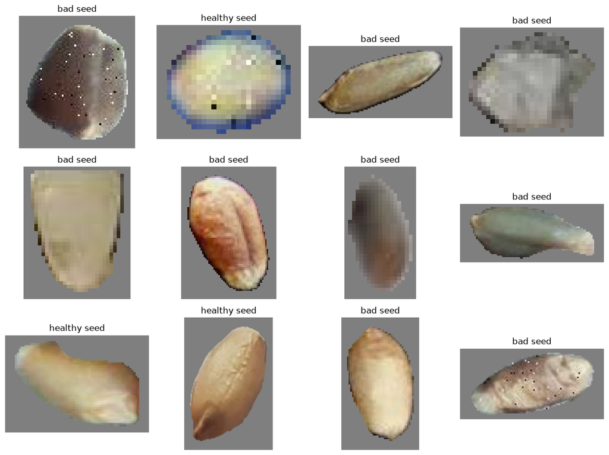

```python
n_show = min(12, len(instances_df))
sample_rows = instances_df.sample(n_show, random_state=RANDOM_STATE)

fig, axes = plt.subplots(3, 4, figsize=(12, 9))
axes = np.array(axes).ravel()

for ax, (_, row) in zip(axes, sample_rows.iterrows()):
    crop = extract_grain_crop(
        row["image_path"],
        row["polygon_px"],
        crop_mode=CROP_MODE,
        padding_ratio=PADDING_RATIO,
        background_value=MASK_BACKGROUND,
    )
    ax.imshow(crop)
    ax.set_title(row["class_name"])
    ax.axis("off")

for ax in axes[n_show:]:
    ax.axis("off")

plt.tight_layout()
plt.show()
```

## 7. Load pretrained DINOv2 — Frozen

```python
# First run downloads the official Meta DINOv2 repo/weights through torch.hub.
# After that, they are usually cached locally.

model = torch.hub.load(
    "facebookresearch/dinov2",
    DINO_MODEL,
    pretrained=True,
)

model = model.to(DEVICE)
model.eval()

for p in model.parameters():
    p.requires_grad = False

num_params = sum(p.numel() for p in model.parameters())
trainable = sum(p.numel() for p in model.parameters() if p.requires_grad)

print(f"Loaded {DINO_MODEL}")
print(f"Parameters: {num_params/1e6:.1f}M")
print("Trainable parameters:", trainable)
```

```
Downloading: "https://github.com/facebookresearch/dinov2/zipball/main" to C:\Users\alool/.cache\torch\hub\main.zip
```

```
Downloading: "https://dl.fbaipublicfiles.com/dinov2/dinov2_vits14/dinov2_vits14_pretrain.pth" to C:\Users\alool/.cache\torch\hub\checkpoints\dinov2_vits14_pretrain.pth
```

```
Loaded dinov2_vits14
Parameters: 22.1M
Trainable parameters: 0
```

## 8. DINOv2 preprocessing

```python
# Baseline: only the preprocessing expected by the pretrained model.
# No extra color-normalization experiment is applied here.

dino_transform = transforms.Compose([
    transforms.Resize(
        (IMAGE_SIZE, IMAGE_SIZE),
        interpolation=transforms.InterpolationMode.BICUBIC
    ),
    transforms.ToTensor(),
    transforms.Normalize(
        mean=(0.485, 0.456, 0.406),
        std=(0.229, 0.224, 0.225),
    ),
])
```

## 9. Build DataLoader

```python
class GrainCropDataset(Dataset):
    def __init__(self, dataframe):
        self.df = dataframe.reset_index(drop=True)

    def __len__(self):
        return len(self.df)

    def __getitem__(self, idx):
        row = self.df.iloc[idx]

        crop = extract_grain_crop(
            row["image_path"],
            row["polygon_px"],
            crop_mode=CROP_MODE,
            padding_ratio=PADDING_RATIO,
            background_value=MASK_BACKGROUND,
        )

        tensor = dino_transform(crop)

        meta = {
            "split": row["split"],
            "image_path": row["image_path"],
            "instance_idx": int(row["instance_idx"]),
            "class_id": int(row["class_id"]),
            "class_name": row["class_name"],
        }
        return tensor, meta


grain_ds = GrainCropDataset(instances_df)

grain_loader = DataLoader(
    grain_ds,
    batch_size=BATCH_SIZE,
    shuffle=False,
    num_workers=0,     # Windows/Jupyter-friendly
    pin_memory=(DEVICE == "cuda"),
)

print("Number of grain instances:", len(grain_ds))
```

```
Number of grain instances: 234796
```

## 10. Extract pretrained DINOv2 embeddings

```python
all_embeddings = []
all_meta = []

use_amp = DEVICE == "cuda"

with torch.inference_mode():
    for images, meta in tqdm(grain_loader, desc="DINOv2 embeddings"):
        images = images.to(DEVICE, non_blocking=True)

        if use_amp:
            with torch.autocast(device_type="cuda", dtype=torch.float16):
                features = model.forward_features(images)
                emb = features["x_norm_clstoken"]
        else:
            features = model.forward_features(images)
            emb = features["x_norm_clstoken"]

        all_embeddings.append(emb.float().cpu().numpy())

        batch_len = len(meta["class_id"])
        for i in range(batch_len):
            all_meta.append({
                "split": meta["split"][i],
                "image_path": meta["image_path"][i],
                "instance_idx": int(meta["instance_idx"][i]),
                "class_id": int(meta["class_id"][i]),
                "class_name": meta["class_name"][i],
            })

embeddings = np.concatenate(all_embeddings, axis=0)

print("Embedding matrix shape:", embeddings.shape)
print("Embedding dimension   :", embeddings.shape[1])
```

```
Embedding matrix shape: (234796, 384)
Embedding dimension   : 384
```

## 11. Save embeddings for later ML experiments

```python
meta_df = pd.DataFrame(all_meta)

embedding_columns = [f"f_{i:04d}" for i in range(embeddings.shape[1])]
embeddings_df = pd.DataFrame(embeddings, columns=embedding_columns)

final_df = pd.concat(
    [meta_df.reset_index(drop=True), embeddings_df],
    axis=1
)

csv_path = OUTPUT_DIR / f"{DINO_MODEL}_grain_embeddings.csv"
npy_path = OUTPUT_DIR / f"{DINO_MODEL}_embeddings.npy"
meta_path = OUTPUT_DIR / f"{DINO_MODEL}_metadata.csv"

final_df.to_csv(csv_path, index=False)
np.save(npy_path, embeddings)
meta_df.to_csv(meta_path, index=False)

print("Saved:")
print(" -", csv_path)
print(" -", npy_path)
print(" -", meta_path)
```

```
Saved:
 - C:\Users\alool\Desktop\Codes\Python\Test_RFDeter\notebooks_Test_DinoV2\outputs_dinov2\dinov2_vits14_grain_embeddings.csv
 - C:\Users\alool\Desktop\Codes\Python\Test_RFDeter\notebooks_Test_DinoV2\outputs_dinov2\dinov2_vits14_embeddings.npy
 - C:\Users\alool\Desktop\Codes\Python\Test_RFDeter\notebooks_Test_DinoV2\outputs_dinov2\dinov2_vits14_metadata.csv
```

## 12. PCA — inspect embedding patterns

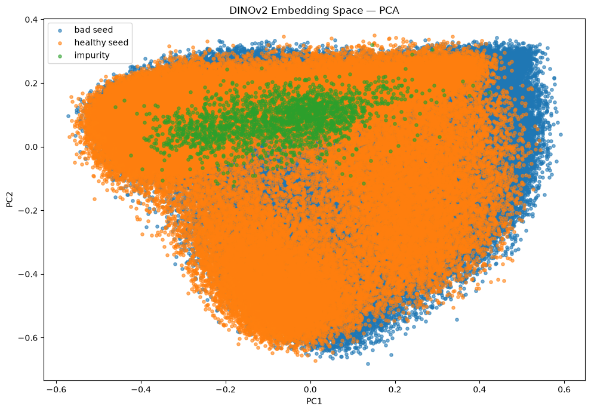

```
Explained variance (PC1 + PC2): 0.2353
```

```python
emb_l2 = normalize(embeddings, norm="l2")

pca = PCA(n_components=2, random_state=RANDOM_STATE)
pca_2d = pca.fit_transform(emb_l2)

plot_df = meta_df.copy()
plot_df["PC1"] = pca_2d[:, 0]
plot_df["PC2"] = pca_2d[:, 1]

plt.figure(figsize=(10, 7))

for class_name, grp in plot_df.groupby("class_name"):
    plt.scatter(
        grp["PC1"],
        grp["PC2"],
        s=14,
        alpha=0.6,
        label=class_name,
    )

plt.xlabel("PC1")
plt.ylabel("PC2")
plt.title("DINOv2 Embedding Space — PCA")
plt.legend()
plt.tight_layout()
plt.show()

print(
    "Explained variance (PC1 + PC2):",
    round(float(pca.explained_variance_ratio_[:2].sum()), 4)
)
```

## 13. Optional t-SNE — non-linear visualization

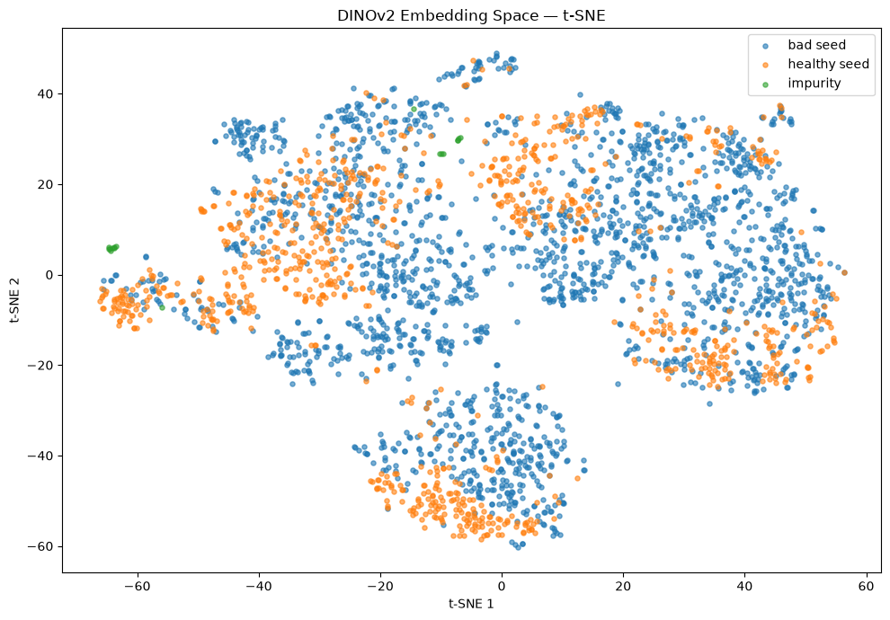

```python
if len(meta_df) > MAX_PLOT_SAMPLES:
    sample_idx = np.random.default_rng(RANDOM_STATE).choice(
        len(meta_df),
        size=MAX_PLOT_SAMPLES,
        replace=False,
    )
else:
    sample_idx = np.arange(len(meta_df))

X_sample = emb_l2[sample_idx]
meta_sample = meta_df.iloc[sample_idx].reset_index(drop=True)

n_components = min(50, X_sample.shape[1], max(2, len(X_sample) - 1))
pca_50 = PCA(n_components=n_components, random_state=RANDOM_STATE)
X_50 = pca_50.fit_transform(X_sample)

perplexity = min(30, max(5, (len(X_50) - 1) // 3))

tsne = TSNE(
    n_components=2,
    perplexity=perplexity,
    init="pca",
    learning_rate="auto",
    random_state=RANDOM_STATE,
)

X_tsne = tsne.fit_transform(X_50)

plt.figure(figsize=(10, 7))

for class_name in sorted(meta_sample["class_name"].unique()):
    mask = meta_sample["class_name"].values == class_name
    plt.scatter(
        X_tsne[mask, 0],
        X_tsne[mask, 1],
        s=14,
        alpha=0.6,
        label=class_name,
    )

plt.title("DINOv2 Embedding Space — t-SNE")
plt.xlabel("t-SNE 1")
plt.ylabel("t-SNE 2")
plt.legend()
plt.tight_layout()
plt.show()
```

## 14. Quantitative class-separability checks

```python
labels = meta_df["class_id"].to_numpy()
unique_labels = np.unique(labels)

if len(unique_labels) >= 2:
    if len(emb_l2) > 5000:
        rng = np.random.default_rng(RANDOM_STATE)
        sil_idx = rng.choice(len(emb_l2), 5000, replace=False)
        sil = silhouette_score(
            emb_l2[sil_idx],
            labels[sil_idx],
            metric="cosine",
        )
    else:
        sil = silhouette_score(
            emb_l2,
            labels,
            metric="cosine",
        )

    print(f"Silhouette score (cosine): {sil:.4f}")
    print("Higher is better; values near 0 indicate strong overlap.")
else:
    print("Silhouette score requires at least 2 classes.")
```

```
Silhouette score (cosine): 0.0359
Higher is better; values near 0 indicate strong overlap.
```

### Class-centroid cosine similarity

```python
centroids = []
centroid_names = []

for class_id, grp in meta_df.groupby("class_id"):
    idx = grp.index.to_numpy()

    centroid = emb_l2[idx].mean(axis=0)
    centroid = centroid / (np.linalg.norm(centroid) + 1e-12)

    centroids.append(centroid)
    centroid_names.append(
        CLASS_NAMES.get(int(class_id), f"class_{class_id}")
    )

centroids = np.stack(centroids)
sim_matrix = cosine_similarity(centroids)

sim_df = pd.DataFrame(
    sim_matrix,
    index=centroid_names,
    columns=centroid_names,
)

display(sim_df.round(3))

print(
    "\nInterpretation: closer to 1 = more similar class centroids. "
    "Lower off-diagonal values suggest better separation."
)
```

|  | bad seed | healthy seed | impurity |
| --- | --- | --- | --- |
| bad seed | 1.000 | 0.953 | 0.692 |
| healthy seed | 0.953 | 1.000 | 0.671 |
| impurity | 0.692 | 0.671 | 1.000 |

```
Interpretation: closer to 1 = more similar class centroids. Lower off-diagonal values suggest better separation.
```

### Nearest-neighbor label consistency

```python
# This does not train a classifier.
# It only checks whether nearby embeddings often share the same known label.

nn_limit = min(5000, len(emb_l2))
rng = np.random.default_rng(RANDOM_STATE)

if len(emb_l2) > nn_limit:
    nn_idx = rng.choice(len(emb_l2), nn_limit, replace=False)
else:
    nn_idx = np.arange(len(emb_l2))

X_nn = emb_l2[nn_idx]
y_nn = labels[nn_idx]

sim = cosine_similarity(X_nn)
np.fill_diagonal(sim, -np.inf)

nearest = sim.argmax(axis=1)
same_class_rate = (y_nn[nearest] == y_nn).mean()

print(f"Nearest-neighbor same-class rate: {same_class_rate:.4f}")
```

```
Nearest-neighbor same-class rate: 0.8448
```

## 15. How to interpret the POC

We are **not** expecting perfect separation from pretrained DINOv2.

We are checking whether the embedding space contains useful structure:

- **Good sign:** same-class grains tend to stay close.
- **Good sign:** classes show visible separation in PCA/t-SNE.
- **Good sign:** positive silhouette score and useful nearest-neighbor consistency.
- **Warning:** classes completely overlap even when labels are reliable.
- **Warning:** embeddings cluster mainly by lighting/background/session instead of grain class.

### Recommended next experiments

1. Keep this as the **pretrained baseline**.
2. Compare `masked` crop vs `bbox` crop.
3. Compare DINOv2-S vs DINOv2-B.
4. Test blur / lower resolution.
5. Test original vs color-normalized images separately.
6. If needed, compare with **fine-tuned DINOv2 embeddings** later.
7. Feed saved embeddings into RF / XGBoost / CatBoost / SVM as a separate downstream experiment.

> When you later train/evaluate ML models, avoid randomly mixing consecutive frames from the same recording across Train/Test. Split by recording/session/batch to reduce data leakage.